# Spatial self-correlation.

J Camilo Fagua

May 2024

# **1) Objectives**

1. Understand the concept of spatial self-correlation and its relationship with the interpolation methods.
2. Learn to perform interpolation methods based on spatial information exclusively.
3. Understand the concept of variogram and its important in the interpolation methods based on spatial data variance.

# **2) Introduction**

Waldo Tobler made famous his “first law of geography,” which states that “everything is related to everything else, but near things are more related than distant things” (Tobler, 1970). Nowadays, data that obey the first law of geography are said to be spatially autocorrelated. The prefix “auto” means “self.” Thus, to say a feature is spatially autocorrelated means etymologically that its attribute values are correlated with attribute values of the same feature at nearby locations (Bandyopadhyay, 2012). Anselin and Bera (1998) provide a concise verbal definition: “spatial autocorrelation can be loosely defined as the coincidence of value similarity with locational similarity.”; For instance, nearby locations would probably tend to have similar mean annual precipitation levels.

Anselin and Bera (1998) provided a more formal definition: a nonzero spatial autocorrelation exists between attributes of a feature defined at locations i and j if the covariance between feature attribute values at those points is nonzero. If this covariance is positive (i.e., if data with attribute values above the mean tend to be near other data with values above the mean), then we say there is positive spatial autocorrelation; if the converse is true, then we say there is negative spatial autocorrelation. Positive autocorrelation is much more common in nature, but negative autocorrelation does exist, for example, in the case of conspecific allelopathy, the tendency of some plants to inhibit the nearby growth of other plants of the same species (Rice, 1984).

**NOTE**: **Correlation** is defined as the extent to which two variables are linearly related. Correlation tells us the strength and the direction of this relationship. **Covariance** is a quantitative measure of the degree to which the deviation of one variable (X) from its mean is related to the deviation of another variable (Y) from its mean. To simplify, covariance measures the joint variability of two random variables. You can find the equations and other details about the difference between correlation and Covariance in this [link](https://www.analyticsvidhya.com/blog/2023/07/covariance-vs-correlation/).

Spatial data (sampling) discussed in this tutorial consist of sets of attribute values Y(x, y) with the coordinates x and y describing the location of one or more attribute values (or response variable(s)). The locations (x, y) are fixed and not random, but the attribute values (Y) are assumed to have a random component. Errors in measuring the location of the phenomenon are incorporated into the uncertainty in the value of the phenomenon at each location. The coordinates (x,y) themselves are assumed to be measured without error.

Since one of the main objectives of spatial modelling is to predict a response variable on the terrain, we have different ways to deal with the prediction of this variable using the principles of spatial autocorrelation; we call these methods spatial interpolations. We can find two groups of spatial interpolations: (1) Methods which are based only on the mathematical calculations of spatial information (i.e., coordinates data) and do not involve spatial changes of data variance. (2) Methods that include in the mathematical calculations spatial changes of data variance.

# **3) Methods based only on spatial information.**

The predictions of these methods can be represented as the weighted averages of sampled data and the same general prediction formula can be presented for them:

$$y(x_0) = {\sum_{i=1}^{n}{lamda_i * y(x_i)}}$$
where $y(x_0)$ is a predicted value of an attribute at the location of interest $x_0$, $y(x_i)$ is observed value at the sampled location $x_i$, $lamda_i$ the weight assigned to the sample at $x_i$, and $n$ represents the number of samples used to generate the predictions. It is important to highlight term attribute is often used in interpolations and is also called primary variable and is equivalent to response variable or dependent variable. The types of methods based only on spatial information change the statistical way to determine the weights ($lamda_i$) (Li, 2022).

**3.1) Exploratory Data Analysis.**

Before starting an interpolation, spatial exploratory data analyses can be done by plotting the measured variable. We are going to load the “sp” and “lattice” libraries and the data meuse (data included in the “sp package), which contains the zinc concentration in a zone of the river Meuse banks.

```r
# To clean environment
rm(list = ls(all.names = TRUE))
gc()
```

```
##          used (Mb) gc trigger (Mb) max used (Mb)
## Ncells 520474 27.8    1156875 61.8   660385 35.3
## Vcells 950521  7.3    8388608 64.0  1772588 13.6
```

```r
#To install packages
#install.packages("lattice")
#install.packages("sp")

library(lattice)
library(sp)
data(meuse)
class(meuse)
```

```
## [1] "data.frame"
```

```r
str(meuse)
```

```
## 'data.frame':    155 obs. of  14 variables:
##  $ x      : num  181072 181025 181165 181298 181307 ...
##  $ y      : num  333611 333558 333537 333484 333330 ...
##  $ cadmium: num  11.7 8.6 6.5 2.6 2.8 3 3.2 2.8 2.4 1.6 ...
##  $ copper : num  85 81 68 81 48 61 31 29 37 24 ...
##  $ lead   : num  299 277 199 116 117 137 132 150 133 80 ...
##  $ zinc   : num  1022 1141 640 257 269 ...
##  $ elev   : num  7.91 6.98 7.8 7.66 7.48 ...
##  $ dist   : num  0.00136 0.01222 0.10303 0.19009 0.27709 ...
##  $ om     : num  13.6 14 13 8 8.7 7.8 9.2 9.5 10.6 6.3 ...
##  $ ffreq  : Factor w/ 3 levels "1","2","3": 1 1 1 1 1 1 1 1 1 1 ...
##  $ soil   : Factor w/ 3 levels "1","2","3": 1 1 1 2 2 2 2 1 1 2 ...
##  $ lime   : Factor w/ 2 levels "0","1": 2 2 2 1 1 1 1 1 1 1 ...
##  $ landuse: Factor w/ 15 levels "Aa","Ab","Ag",..: 4 4 4 11 4 11 4 2 2 15 ...
##  $ dist.m : num  50 30 150 270 380 470 240 120 240 420 ...
```

Mapping shows that zinc concentration is larger close to the river Meuse banks.

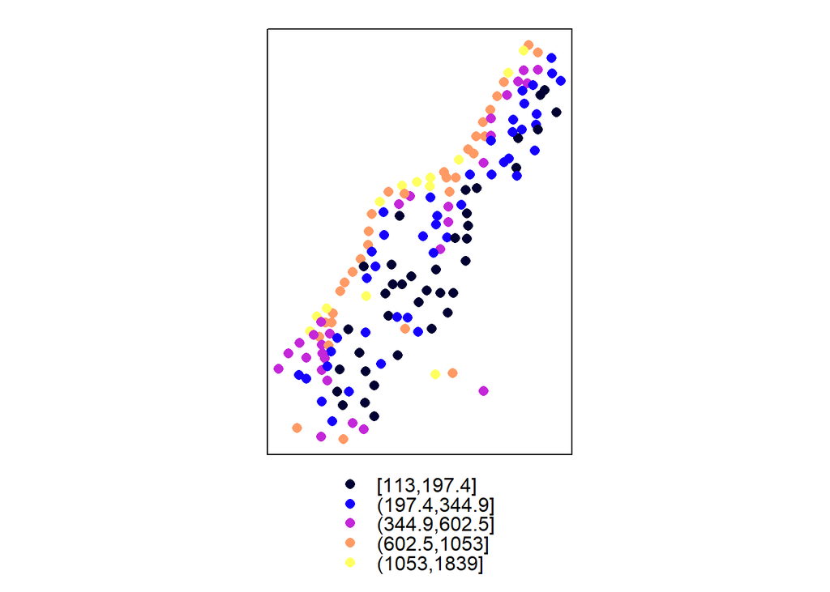

```r
coordinates(meuse) = c("x", "y")# To indicate spatial coordinates in sp.
spplot(meuse, "zinc", do.log = T)
```

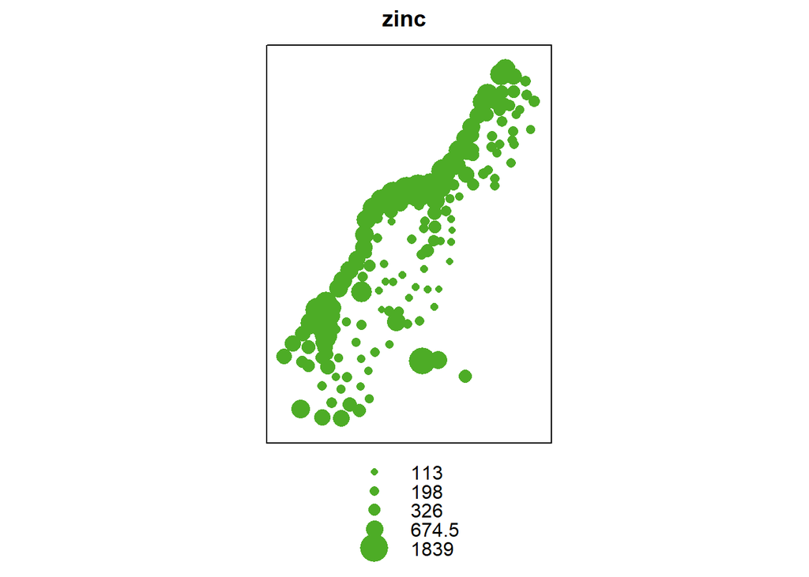

```r
#do.log
#logical; if TRUE use log-linear scale to divide range in equal
#cuts, else use a linear scale if cuts is only number of cuts.
#spplot(meuse, "zinc", do.log = F)

bubble(meuse, "zinc", do.log = T, key.space = "bottom")
```

The linear regression and plot between the Logarithm of the zinc concentration and the square root of the distance from the river shows that the concentration decreases as you move away from the river.

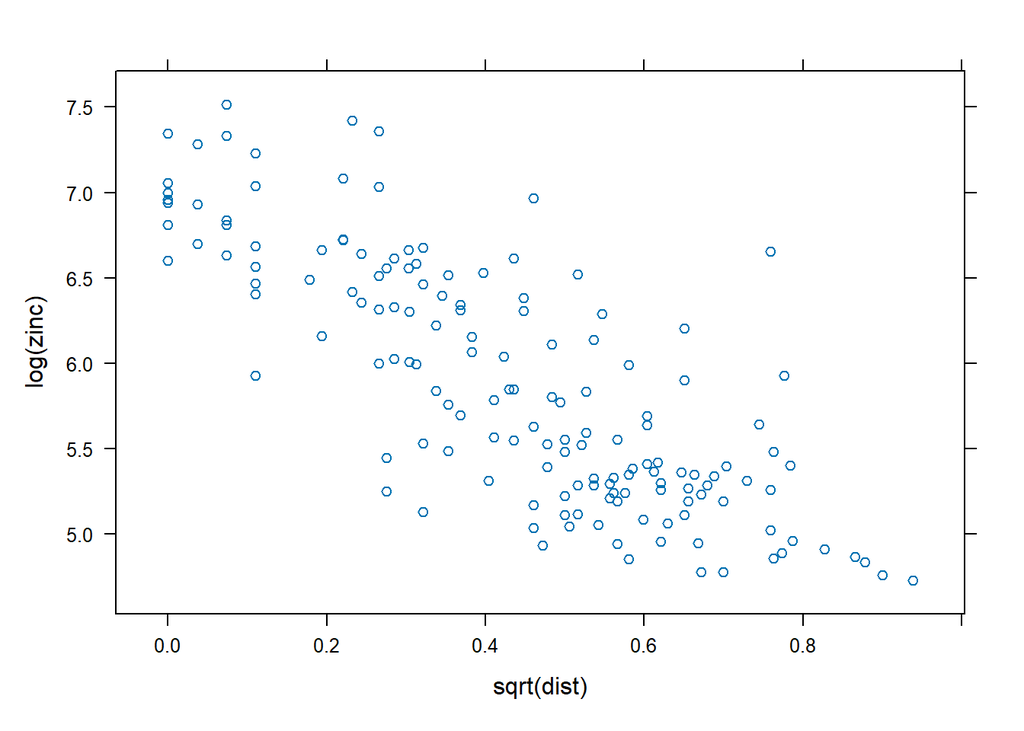

```r
xyplot(log(zinc) ~ sqrt(dist), as.data.frame(meuse))
```

```r
zn.lm = lm(log(zinc) ~ sqrt(dist), meuse)
summary(zn.lm)
```

```
##
## Call:
## lm(formula = log(zinc) ~ sqrt(dist), data = meuse)
##
## Residuals:
##      Min       1Q   Median       3Q      Max
## -1.04624 -0.29060 -0.01869  0.26445  1.59685
##
## Coefficients:
##             Estimate Std. Error t value Pr(>|t|)
## (Intercept)  6.99438    0.07593   92.12   <2e-16 ***
## sqrt(dist)  -2.54920    0.15498  -16.45   <2e-16 ***
## ---
## Signif. codes:  0 '***' 0.001 '**' 0.01 '*' 0.05 '.' 0.1 ' ' 1
##
## Residual standard error: 0.4353 on 153 degrees of freedom
## Multiple R-squared:  0.6388, Adjusted R-squared:  0.6364
## F-statistic: 270.6 on 1 and 153 DF,  p-value: < 2.2e-16
```

We can also plot maps with fitted values and their residuals (predicted value less mean of predicted values) to show dependency of the attribute on (x,y). Although the trend removes a large part of the variability, the residuals do not appear to behave as spatially unstructured.

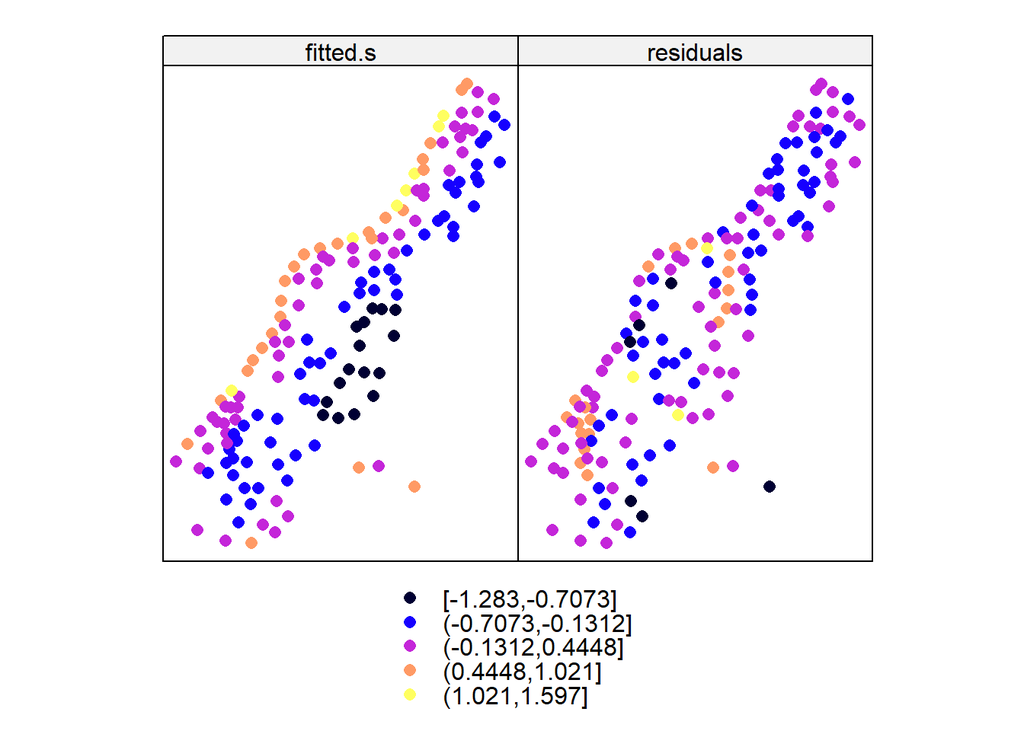

```r
meuse$fitted.s = predict(zn.lm, meuse) - mean(predict(zn.lm,meuse))
meuse$residuals = residuals(zn.lm)
spplot(meuse, c("fitted.s", "residuals"))
```

```r
#spplot(meuse, c("fitted.s"))
#spplot(meuse, c("residuals"))
```

Usually, interpolations are done on a regular grid. For the Meuse data set, coordinates of points on a regular grid are already defined in the meuse.grid data.frame, and are converted into a SpatialPixelsDataFrame:

```r
data(meuse.grid)
class(meuse.grid)
```

```
## [1] "data.frame"
```

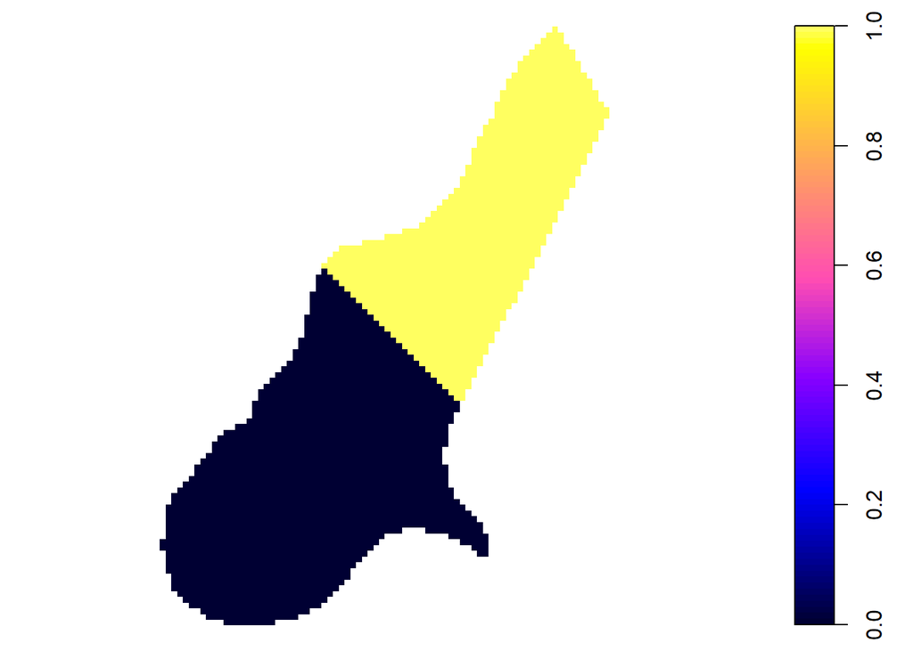

```r
coordinates(meuse.grid) = c("x", "y")
meuse.grid = as(meuse.grid, "SpatialPixelsDataFrame")
plot(meuse.grid)
```

**3.2) Inverse Distance Weighted (IDW).**

This interpolation method,IDW, predicts the value of an attribute at an unsampled location using a linear combination of values of samples weighted by an inverse function of the distance from the location of interest to the sampled locations. The assumption is that sampled locations closer to the unsampled location are more similar to it than those further away in their values (Li, 2022).

$$lamda_i = (1/d_i^{n}) / {\sum_{i=1}^{n}{1/d_i^{p}}}$$

where $d_i$ is the distance between $x_0$ and $x_i$, p is a distance weighting power parameter, and n represents the number of samples to be used. The main factor affecting predictive accuracy of IDW is the value of the distance weighting power parameter (p). The number of samples used is also an important factor for the accuracy. Weights diminish as the distance increases, especially when the value of p increases, so nearby samples have a heavier weight and thus have more influence on the predictions.

To run IDW, we are going to install and load the library [gstat](https://cran.r-project.org/web/packages/gstat/index.html) for Spatial and Spatio-Temporal Geostatistical Modelling, Prediction and Simulation. The function idw() does the statistical test. The output variable is called var1.pred, and the var1.var values are NA because inverse distance does not provide prediction error variances.

```r
#install.packages("gstat")
library(gstat)
idw.out = idw(zinc ~ 1, meuse, meuse.grid, idp = 2)
```

```
## [inverse distance weighted interpolation]
```

```r
class(idw.out)
```

```
## [1] "SpatialPixelsDataFrame"
## attr(,"package")
## [1] "sp"
```

```r
str(idw.out)
```

```
## Formal class 'SpatialPixelsDataFrame' [package "sp"] with 7 slots
##   ..@ data       :'data.frame':  3103 obs. of  2 variables:
##   .. ..$ var1.pred: num [1:3103] 634 713 654 604 857 ...
##   .. ..$ var1.var : num [1:3103] NA NA NA NA NA NA NA NA NA NA ...
##   ..@ coords.nrs : int [1:2] 1 2
##   ..@ grid       :Formal class 'GridTopology' [package "sp"] with 3 slots
##   .. .. ..@ cellcentre.offset: Named num [1:2] 178460 329620
##   .. .. .. ..- attr(*, "names")= chr [1:2] "x" "y"
##   .. .. ..@ cellsize         : Named num [1:2] 40 40
##   .. .. .. ..- attr(*, "names")= chr [1:2] "x" "y"
##   .. .. ..@ cells.dim        : Named int [1:2] 78 104
##   .. .. .. ..- attr(*, "names")= chr [1:2] "x" "y"
##   ..@ grid.index : int [1:3103] 69 146 147 148 223 224 225 226 300 301 ...
##   ..@ coords     : num [1:3103, 1:2] 181180 181140 181180 181220 181100 ...
##   .. ..- attr(*, "dimnames")=List of 2
##   .. .. ..$ : chr [1:3103] "1" "2" "3" "4" ...
##   .. .. ..$ : chr [1:2] "x" "y"
##   ..@ bbox       : num [1:2, 1:2] 178440 329600 181560 333760
##   .. ..- attr(*, "dimnames")=List of 2
##   .. .. ..$ : chr [1:2] "x" "y"
##   .. .. ..$ : chr [1:2] "min" "max"
##   ..@ proj4string:Formal class 'CRS' [package "sp"] with 1 slot
##   .. .. ..@ projargs: chr NA
```

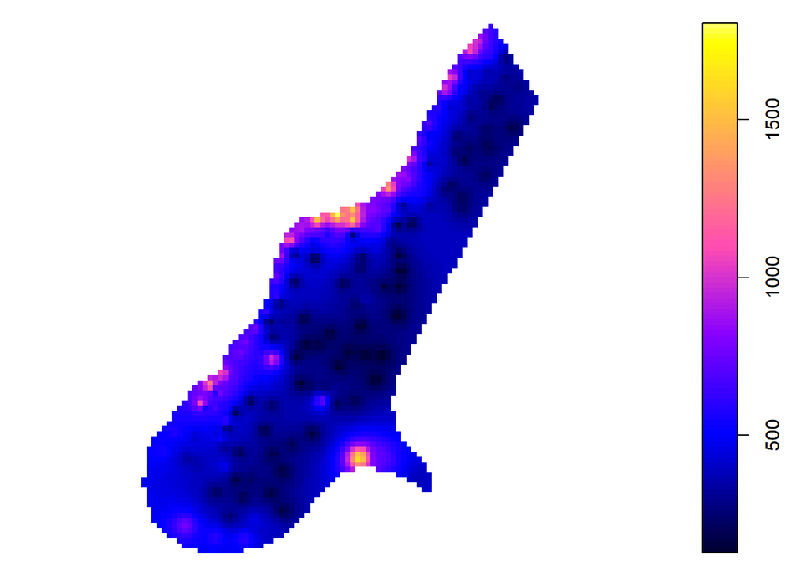

```r
plot(idw.out)
```

```r
as.data.frame(idw.out)[1:5, ]
```

```
##        x      y var1.pred var1.var
## 1 181180 333740  633.6864       NA
## 2 181140 333700  712.5450       NA
## 3 181180 333700  654.1617       NA
## 4 181220 333700  604.4422       NA
## 5 181100 333660  857.2558       NA
```

You can divide the sample data in training and testing as we have done during the whole course to estimate the errors of this interpolation. IDW is called Inverse Distance Squared (IDS) if p = 2, a commonly used option for IDW (as we did). You also can tune different values of p looking for the best model; p is usually tuned with values between 2 and 20.

IDW ignores the spatial configuration of observations since it only considered distances to the predicted location; this may lead to undesired effects if the observation locations are strongly clustered. Another important point is that weights are guaranteed to be between 0 and 1, resulting in interpolated values never outside the range of observed values.

**3.3) Linear Regression.**

Linear regression model can be used for spatial interpolation, we are going to run it using the function lm(). The next script runs again the logarithm of zinc concentration as response variable and the distance to the river as predictor variable (Li, 2022).

```r
zn.lm = lm(log(zinc) ~ sqrt(dist), meuse)
zn.lm
```

```
##
## Call:
## lm(formula = log(zinc) ~ sqrt(dist), data = meuse)
##
## Coefficients:
## (Intercept)   sqrt(dist)
##       6.994       -2.549
```

```r
meuse.grid$pred = predict(zn.lm, meuse.grid)
meuse.grid$se.fit = predict(zn.lm, meuse.grid, se.fit = TRUE)$se.fit
class(meuse.grid)
```

```
## [1] "SpatialPixelsDataFrame"
## attr(,"package")
## [1] "sp"
```

Now, we can plot the resulting map, passing the linear regression prediction (“pred”) to a raster created from the meuse.grid (a SpatialPixelsDataFrame).

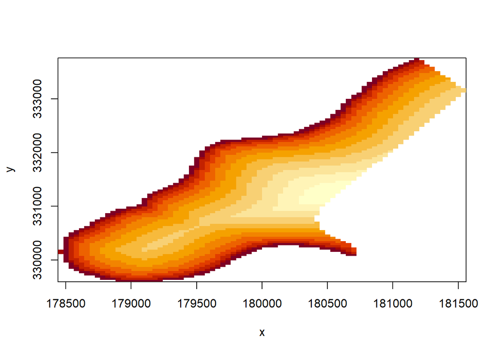

```r
library(raster)
zn.lm.raster = raster(meuse.grid["pred"])
image(zn.lm.raster,useRaster = T)
```

# **4) Methods based on spatial changes of data variance.**

**4.1) The Variogram.**

In geostatistics the spatial correlation is modeled by the variogram (also caleed semivariogram) instead of a correlogram or covariogram. Variogram plots the semivariance (semi) of the attribute (Y or response variable) as function of distance, where the semivariance is defined as a half the variance of the differences between all possible points spaced a constant distance (Li, 2022).

$$semi = (x_i, x_0) = semi(h) = var [Y(x_i) - Y(x_0)]/2$$

where Y is the attribute, h is the distance between data point Xi and Xo, and semi(h) is the semivariogram.

Variogram states that the variance of Y is constant, and that spatial correlation of Y does not depend on location, but only on separation distance h. The variogram allows to plot all possible pairs of Y and their estimated correlations. If we further assume isotropy (direction independence of semivariance), we can plot the absolute value of the distances. This estimate is called the sample variogram.

First, we are going to plot the variogram cloud (the plot of all possible squared differences of observation pairs against their separation distance).

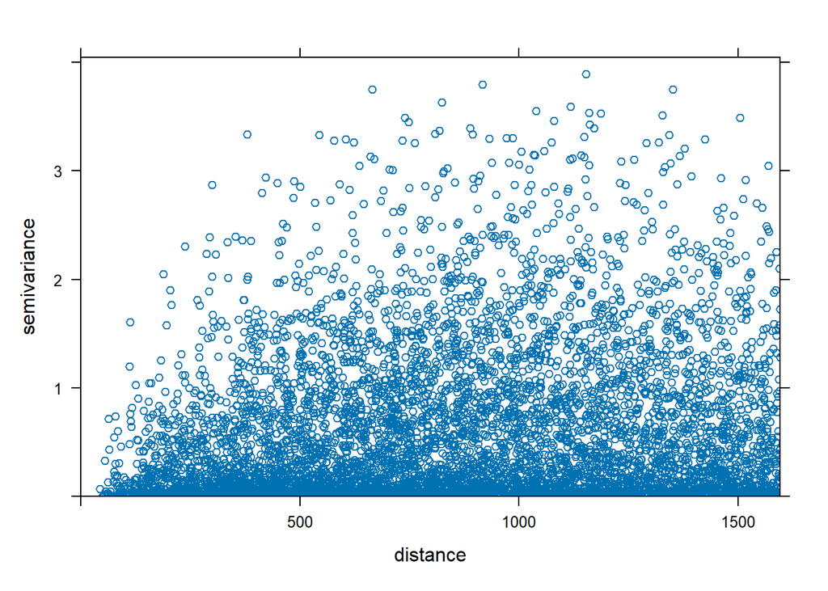

```r
plot(variogram(log(zinc) ~ 1, meuse, cloud = TRUE))
```

We can smooth the variation of the variogram cloud by averaging the cloud values over distance intervals to provides an estimate of semivariance. The ~ 1 defines a single constant predictor.

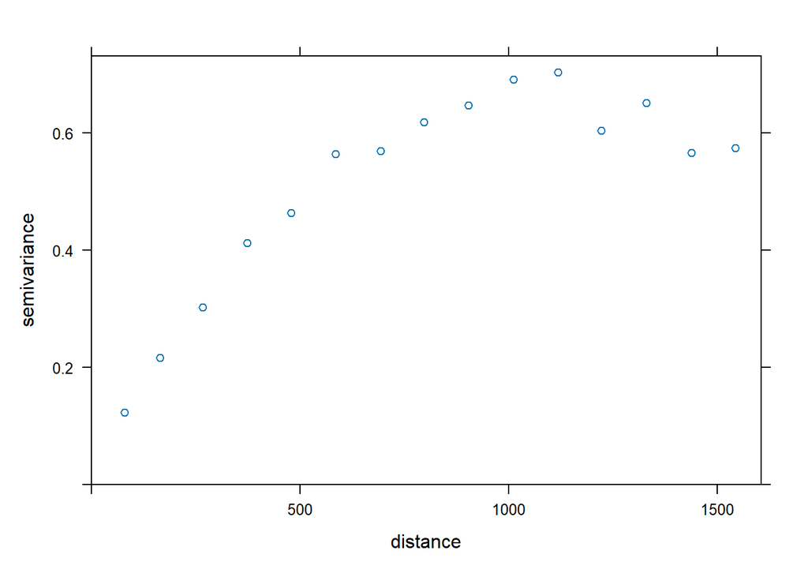

```r
plot(variogram(log(zinc) ~ 1, meuse))
```

The next script fits a variogram model using the sample data. The function vgm() generates this model and their argument “Sph” indicates the selected function, a spherical model.

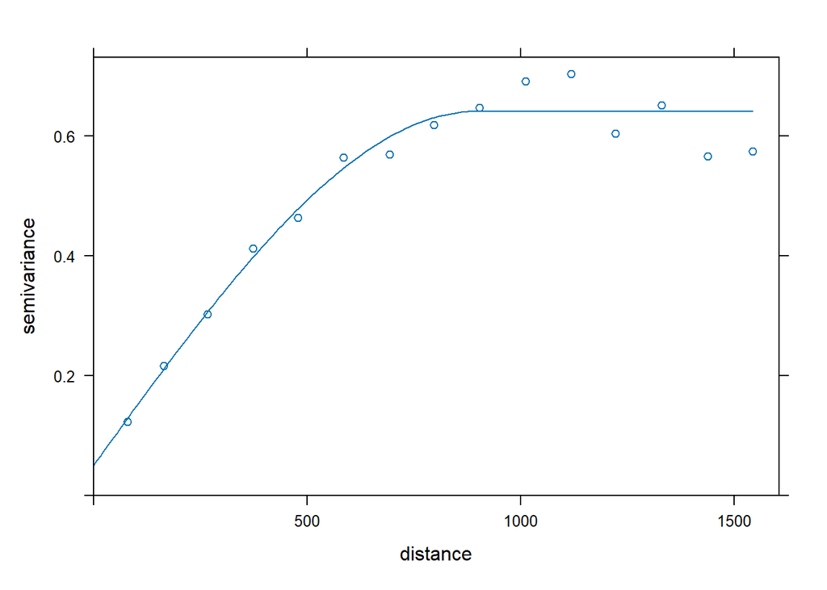

```r
vgm1 = variogram(log(zinc) ~ 1, meuse)
model.1 = fit.variogram(vgm1,vgm("Sph"))
plot(vgm1, model=model.1)
```

Why is a variogram built and used in some interpolations? (1) The variogram tests if the semivariance of the attribute variable (response variable) increases with the separation of the points, evidencing a spatial process. (2) Variogram is the basis of various prediction and simulation algorithms, such as kriging (Li, 2022).

Kriging also known as Gaussian process regression, is a method of interpolation based on Gaussian process governed by covariances. Kriging produces the most probably linear unbiased prediction at unsampled locations by computing a weighted average of the known attribute values of the Kriging function (lamda) in a neighborhood of the point to interpolate. The predictions of simple kriging are based on the next equation, which is a modified version of the general equation presented at the beginning of this tutorial (Li, 2022).

$$Y(x_0) = {\sum_{i=1}^{n}{lamda_1 y(x_i)}} +
[1-{\sum_{i=1}^{n}{lamda_1}}]U$$

where U is a known stationary mean, assumed to be constant over the whole domain and calculated as the average of sample data.

Since observations are considered independent, we first need to estimate the ordinary least squares residuals to estimate a kriging (regular regression residuals). We later estimate the variogram model to define the covariance structure. At the end, the function fit.variogram() fit the variogram Model to the sample Variogram to estimate the values for the parameters Nugget (it reflects the variance of sampling errors agree with the distance) and spherical model. These values are going to be included in the kriging estimation.

```r
f = log(zinc) ~ sqrt(dist)
vt = variogram(f, meuse)
vt.fit = fit.variogram(vt, vgm("Sph"))
vt.fit
```

```
##   model      psill    range
## 1   Nug 0.07981792   0.0000
## 2   Sph 0.14905756 872.7236
```

```r
lz.sk = krige(log(zinc) ~ 1, meuse, meuse.grid, vt.fit)
```

```
## [using ordinary kriging]
```

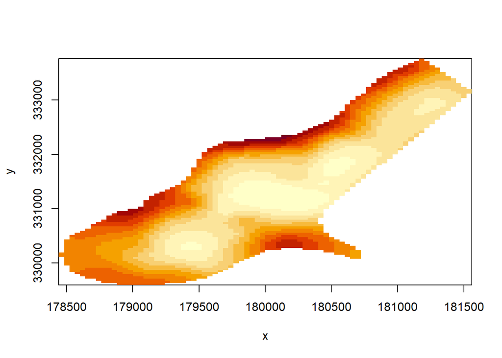

```r
meuse.grid$pred = lz.sk$var1.pred
lz.sk.raster = raster(meuse.grid["pred"])
image(lz.sk.raster,useRaster = T)
```

# **Cited literature.**

Anselin, L., and A. K. Bera (1998). Spatial dependence in linear regression models with an introduction to spatial econometrics. In Ullau, A. and Giles, D. E. A., Editors. Handbook of Applied Economic Statistics pp. 237-289. Marcel Dekker, New York

Bandyopadhyay, D., 2012. Richard E. Plant: Spatial Data Analysis in Ecology and Agriculture Using R. J. Agric. Biol. Environ. Stat. 17, 700-701. https://doi.org/10.1007/s13253-012-0112-z

Bivand, R., Pebesma, E., Gomez-Rubio, V., 2013. Applied Spatial Data Analysis with R, 2nd ed. Springer, New York, US.

Li, J. (2022). Spatial Predictive Modeling with R (1st ed.). Chapman and Hall/CRC. https://doi.org/10.1201/9781003091776.

Rice, E. L. (1984). Allelopathy. Academic Press, New York

Tobler, W.R., 1970. COMPUTER MOVIE SIMULATING URBAN GROWTH IN DETROIT REGION. Econ. Geogr. 46, 234-240. https://doi.org/10.2307/143141